# Cafriplots & sa boîte à outils : le package R CafriplotsR

Colloque Ressac, Libreville 25/11/2025

## Le contexte général

La collecte et la compilation des données de biodiversité ont été **transformées** par le développement d’outils et de plateformes globales (p.ex. GBIF).

Pourtant

L’accès à des données standardisées et à jour reste **inégal et insuffisant** en particulier dans les régions à forte biodiversité.

Cet accès limité complique n’importe quelle initiative visant à évaluer les **multiples dimensions de la biodiversité végétale**.

## Accessibilité en données primaires de biodiversité végétale en Afrique centrale

Des dépôts de données globaux et de meilleures pratiques d’archivage font que les **données d’occurrences** sont aujourd’hui beaucoup plus accessibles (p.ex. GBIF)

**C’est moins le cas pour d’autres types de données “primaires” :**

- Données d’inventaires forestiers
- Traits fonctionnels (ou n’importe quel attribut attribué à un taxa) au sens large
- Données de recensement de parcelles permanentes

**Question qui peut paraître trivial** : Où et quand les forêts d’Afrique centrale ont-elles fait l’objet d’inventaires ?

## L’accessibilité

**Un facteur important : le temps écoulé depuis la collecte des données.**

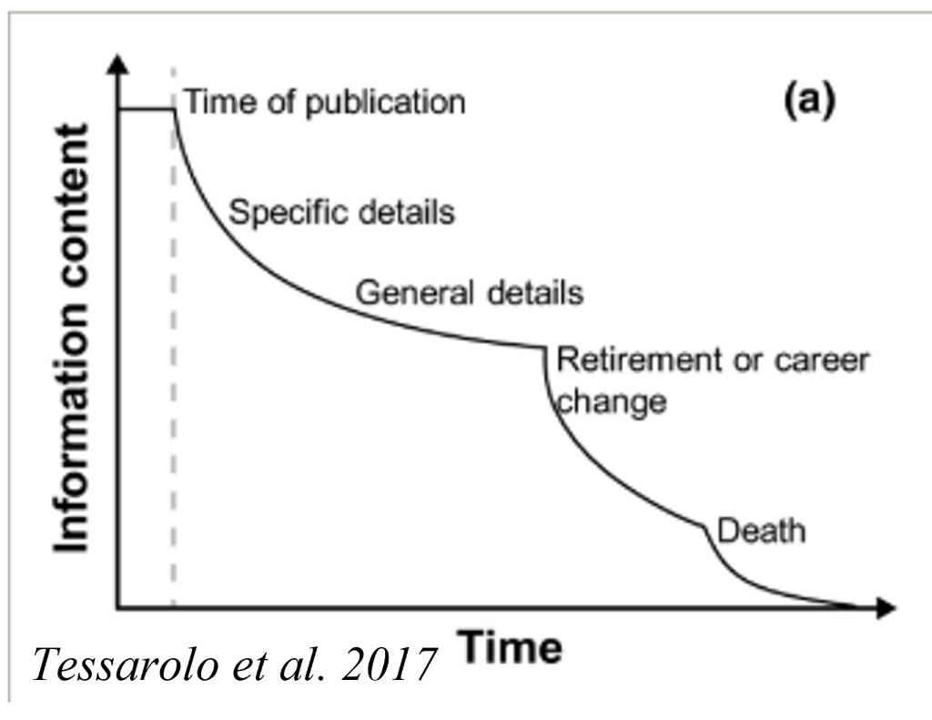

L’accessibilité aux données diminuent avec le temps

- Mauvaises pratiques d’archivage
- Pas de ressources pour maintenir cet accès au-delà des projets

## Problèmes d’accessibilité aux données

## Le défi de la compilation de différents types de biodiversité primaire

Combiner **traits, inventaires, occurrences, statuts de conservation** - en réalité n’importe quel attribut que l’on peut associer à un taxa - pose des problèmes :

- **Manque de reproductibilité** : Chaque chercheur peut parfois refaire le travail depuis zéro (avec des résultats différents)
- **Manque de visibilité** : Les jeux de données compilés dans le cadre de projets/articles manquent de visibilité, et ne sont pas réutilisés
- Problème récurrent : **Évolution continue de la classification taxonomique** : Un nom d’espèce aujourd’hui peut être un synonyme demain –> Une compilation peut ne plus être d’actualité et la remettre à jour est chronophage

## Cafriplots

1. Partager une **gestion** commune
   - Référentiel(s) taxonomique et structures communs
2. Tout en maintenant la **souveraineté** des données et leur gestion
3. **Faciliter le partage et l’intégration** dse données entre réseaux
4. Partager des scripts/applications **reproductibles** à des fins didactiques et de recherche. Par exemple, le script accessible sur les estimations de biomasse. On peut envisager à court terme des tutoriels sur les estimations de diversité taxonomique et phylogénétique.
5. **Accroître la visibilité** de ses réseaux et de ses données, y inclus des données historiques (en voie de disparition), entre nous (communauté des scientifiques d’Afrique centrale) et au dela.

## Cafriplots : Un réseau de réseaux

### Ce n’est pas (que) une plateforme de données

### C’est un **réseau de réseaux**

## CafriplotsR : La boîte à outils

| Bénéfice | Description |
| --- | --- |
| **Standardisation** | Données standardisées |
| **Reproductibilité** | Reproduction d’analyses facilitée |
| **Données complémentaires** | Traits, occurrences, statuts de conservation accessible à tous |
| **Suivi taxonomique** | Avancées taxonomiques se repercutant sur les données, garantissant leur mise à jour |
| **Contextualisation des données** | Dans un contexte biogéographique et fonctionnel régional |

## FAQ: Pourquoi pas GBIF, TRY, forestplot.net ?

Ces outils globaux ont des **processus de partage plutôt unilatéraux** :

- Apports fantastiques pour des études à **larges échelles**
- Mais peu d’intérêt pour des approches à **plus petites échelles**
- **Interactions faibles (voire nulles)** entre collecteurs, curateurs et utilisateurs
- Pas de **co-construction** ni de **co-gestion**

> **L’échelle régionale (biome) fait sens** des points de vue biogéographique et de gestion, et rend plus réalistes ces interactions.

## FAQ: Quels types d’inventaire ?

- cafriplots se dédie pour le moment aux parcelles permanentes
- Mais la plateforme, et les outils de CafriplotsR, est tout à fait adaptée à n’importe quel type d’inventaires. De fait, la platforme contient de nombreux types d’inventaires : transects, parcelle 40x40 m, permanent et pas permanent

## FAQ: Faut-il nécessairement contribuer pour avoir accès aux outils ?

- Non. Par exemple, l’application de standarisation taxonomique peut s’avérer être utile pour n’importe qui intéressé pour standardiser ses données de biodiversité végétale.

## FAQ: Est ce que mes données seront également visibles (et donc accessibles) aux autres réseaux ?

- Non. L’infrastructure et la gestion se fait dans la même base de données mais chacun (groupe de recherche, réseau, individu, …) est seul à avoir accès à ses données.
- Par contre, si il y a besoin, que ce soit de manière ponctuelle ou dans la durée, de combiner des jeux de données, c’est grandement facilité.

## FAQ: Il y a un référentiel taxonomique commun, certes, mais si je ne suis pas satisfait de celui-ci ?

A court terme, il sera possible de passer d’un référentiel à un autre (worldflora). A terme, on peut envisager des modifications suggérés par les utilisateurs sur le référentiel existant.

Cela dit, l’avantage du référentiel existant est de pouvoir ‘créér’ des morpho-espèces (et ainsi de ne pas devoir se calquer à des référentiels ‘officiels’ qui ne sont jamais totalement satisfaisant).

## FAQ: Si je meurs demain, est ce que tout ça ne pas s’effronder ?

Non. En tout cas pas tout de suite. Il est vrai que l’infrastucture mise en place à ce stade dépend de ma personne mais l’ensemble reste solide dans le sens ou il peut être pris en main par d’autres. Si l’on parvient effectivement à rallier d’autres réseaux à cet initiative, alors je peux rendre l’ensemble pérenne à l’échelle de mon unité de recherche.

## Le cercle vertueux qu’on peut envisager

On importe ses données dans le réseau, on enrichit les informations que l’on peut aggréger à différentes échelles taxonomiques (p.ex. diamètres moyen et maximale) ou géographique (distribution et abondances des espèces) et on profite des enrichissement fait par les autres réseaux. Solution gagnante-gagnante.

## Co-construction avec les jeunes chercheurs

L’implication des (jeunes) chercheurs qui manipulent régulièrement des données est **essentielle** pour :

- **Identifier les besoins réels** du terrain
- **Développer des outils adaptés** aux usages concrets
- **Assurer la pérennité** et l’évolution du réseau
- **Former la prochaine génération (et actuelle)** aux bonnes pratiques pour améliorer la visbilité, harmonisation et pérennisation des données

## Comment fonctionne la base de données ?

Principe clé d’une **base de données relationnelle** :

Chaque entité possède un **identifiant unique (ID)** qui ne change jamais :

| Entité | Identifiant | Exemple |
| --- | --- | --- |
| Parcelle | `id_plot` | 1, 2, 3… |
| Individu (arbre) | `id_n` | 12345 |
| Taxon | `idtax_n` | 67890 |
| Trait | `id_trait` | 1, 2, 3… |

> Les **noms peuvent changer** (parcelle renommée, synonyme taxonomique), mais l’**ID reste stable**.

## Pourquoi c’est important ?

**Exemple concret :**

- Vous enregistrez *“Celtis tessmanii”* → la base attribue `idtax_n = 12345`
- Plus tard, les taxonomistes décident que c’est un synonyme de *“Celtis mildbraedii”*
- **Vos données ne sont pas perdues !** L’ID `12345` pointe maintenant vers le nom accepté

**Même principe pour les parcelles :**

- La parcelle “Plot_A” devient “Makokou_01” → `id_plot = 5` reste inchangé
- Toutes les mesures associées restent liées

> **C’est la force d’une base de données : les relations sont basées sur des ID, pas sur des noms.**

## Ce que nous allons faire aujourd’hui

1. **Se connecter** à la base de données
2. **Apprendre à explorer** les parcelles et données disponibles
3. **Standardiser** vos données (taxonomiques)
4. **Enrichir** vos données (contextualiser)
5. **Préparer** l’import de vos propres données